# Statistical inference with the GSS data

## Setup

### Load packages

```r
library(ggplot2)
library(dplyr)
library(statsr)
library(data.table)
```

### Load data

Make sure your data and R Markdown files are in the same directory. When loaded your data file will be called `gss`. Delete this note when before you submit your work.

```r
load("gss.Rdata")
```

## Part 1: Data

**Data collection method:** The household address was randomly selected from a scientific sample designed to represent a cross-section of the country. All households from across the country had an equal chance of being selected for this survey. The observations in the sample are collected by interview.

**The scope of inference (generalizability / causality):** Random sampling was uesd, so results can be used to make correlation statements, and they can be generalized to the population. Random assignment was not uesd,so results can not be used to make causal conclusions.

**Biases:** Non-response sample bias might happened, if only a non-random fraction of the randomly sampled people respond to a survey.

## Part 2: Research question

With the progress of the country and economic development, whether all benefit from this, whether different people benefit from different degrees.

> Does there appear to be a relationship between class and living standard compared to parents?

One of the variables is subjective class identification(`class`), and that only has four levels, the lower class, the working class, the middle class, and the upper class, and the other variable is living standard compared to parents(`parsol`), and that has five levels, much better, somewhat better, about the same, somewhat worse, or much worse.

## Part 3: Exploratory data analysis

NOTE: Insert code chunks as needed by clicking on the “Insert a new code chunk” button (green button with orange arrow) above. Make sure that your code is visible in the project you submit. Delete this note when before you submit your work.

```r
options(dplyr.width = Inf)
parsol_class <- gss %>% filter(!is.na(parsol) & !is.na(class)) %>% group_by(class) %>% summarise(MuchBetter = sum(parsol == 'Much Better')/n(), SomewhatBetter = sum(parsol == 'Somewhat Better')/n(), AboutTheSame = sum(parsol == 'About The Same')/n(), SomewhatWorse = sum(parsol == 'Somewhat Worse')/n(), MuchWorse = sum(parsol == 'Much Worse')/n())
parsol_class
```

```
## # A tibble: 4 x 6
##           class MuchBetter SomewhatBetter AboutTheSame SomewhatWorse  MuchWorse
##          <fctr>      <dbl>          <dbl>        <dbl>         <dbl>      <dbl>
## 1   Lower Class  0.1846453      0.2507289    0.1895044    0.20505345 0.17006803
## 2 Working Class  0.2933651      0.3125558    0.2261232    0.13150848 0.03644749
## 3  Middle Class  0.3714374      0.3153597    0.2147589    0.08103528 0.01740872
## 4   Upper Class  0.5522682      0.2090730    0.1696252    0.05128205 0.01775148
```

We group poeple by different class, and calculate the proportion of different standard of living compared to parents.

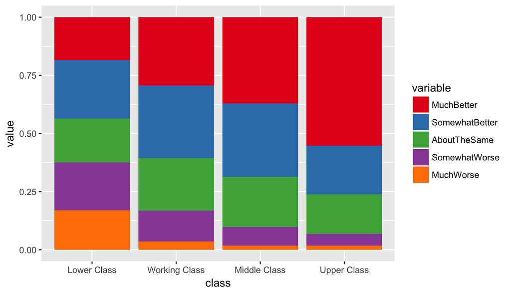

```r
melt_dt <- melt(parsol_class, id=c("class"), measure.vars=c("MuchBetter","SomewhatBetter","AboutTheSame","SomewhatWorse","MuchWorse"))
ggplot(melt_dt, aes(fill=variable, y=value, x=class)) +
    geom_bar( stat="identity", position="fill") +
    scale_fill_brewer(palette = "Set1")
```

From the plot, we can see that the higher the class, the higher proportion of standard of living better than parents and the lower proportion of standard of living worse than parents.

## Part 4: Inference

NOTE: Insert code chunks as needed by clicking on the “Insert a new code chunk” button (green button with orange arrow) above. Make sure that your code is visible in the project you submit. Delete this note when before you submit your work.

### State hypotheses

H0(nothing going on): Class and living standard compared to parents is independent. Living standard compared to parents is no difference between different class.

HA(something going on): Class and living standard compared to parents is dependent. Living standard compared to parents is difference between different class.

### Check conditions

```r
dim(gss)[1]
```

```
## [1] 57061
```

The number of observations is far less than population.

```r
tbl <- table(gss$class, gss$parsol, exclude = "No Class", useNA = "no")
chisq.test(tbl)$expected
```

```
##
##                 Much Better Somewhat Better About The Same Somewhat Worse
##   Lower Class      338.5814        314.7907       222.9070      114.90698
##   Working Class   2211.8019       2056.3878      1456.1523      750.63625
##   Middle Class    2135.7938       1985.7205      1406.1119      724.84080
##   Upper Class      166.8229        155.1010       109.8288       56.61597
##
##                 Much Worse
##   Lower Class     37.81395
##   Working Class  247.02176
##   Middle Class   238.53292
##   Upper Class     18.63136
```

We get expected counts of each cell, and each cell has at least 5 expected counts.

**1. Independence:** Sampled observations must be Independent.

- The data was selected randomly.
- The number of observations is far less than population, n < 10% of population.
- One can only be in one class, and there is only one state of living standard compared to parents. So each case only contributes to one cell in the table.

**2. Sample size:** Each cell has at least 5 expected counts.

**All conditions are met.**

### State the method(s) to be used and why and how

- There are two categorical variables, and both with more than 2 levels. We use Chi-square test of independence to evaluate the independence of two categorical variables where at least one has more than two levels.
- There is no such thing as a chi-square confidence interval for proportions, since in the case of a categorical variables with many levels, there isn’t one parameter to estimate. So hypothesis test only.
- We use theoretical based methods, because expected sample size condition met.
- Chi-square test of independence is used to evaluate the independence of two categorical variables where at least one has more than two levels. We use Chi-square test to get a p-value, and determine whether reject the null hypothesis.

### Perform inference

```r
tbl <- table(gss$class, gss$parsol, exclude = "No Class", useNA = "no")
tbl
```

```
##
##                 Much Better Somewhat Better About The Same Somewhat Worse
##   Lower Class           190             258            195            211
##   Working Class        1972            2101           1520            884
##   Middle Class         2411            2047           1394            526
##   Upper Class           280             106             86             26
##
##                 Much Worse
##   Lower Class          175
##   Working Class        245
##   Middle Class         113
##   Upper Class            9
```

```r
chisq.test(tbl)
```

```
##
##  Pearson's Chi-squared test
##
## data:  tbl
## X-squared = 987.58, df = 12, p-value < 2.2e-16
```

### Interpret results

With a small p value, we reject the null hypothesis in favor of the alternative. Which means that these data provide convincing evidence that relationship class and living standard compared to parents is associated(dependent).